# Assignment 3 - Summer 2025

Author

**Satriale Freight Solutions, a small logistics company headquartered in North Jersey, was founded by Corrado “Junior” Soprano and is now managed day-to-day by his nephew, Tony. In an effort to modernize the business and make it more competitive with regional carriers, Tony hires a data analyst (you) to optimize delivery performance and improve budgeting.**

**Your first task is to estimate the revenue (*Revenue*; in thousands of dollars) generated by each of the company’s 22 rural delivery zones. To do this, you will build a model using two variables: the distance from each zone to the central warehouse in Newark (*Distance*; miles) and the local population (*Population*; hundreds of people) in the communities each zone serves. Tony wants the model to help guide decisions on where to invest in new trucks or consolidate underperforming routes.**

```r
# DO NOT EDIT THIS CHUNK
library(tidyverse)
library(gsheet)
library(ssstats)
airline_data <- gsheet2tbl('https://docs.google.com/spreadsheets/d/10ZN0jMYdVsG2ucIJFSTquVRW916Jj-JmZIGQuqSQhy0/edit?usp=sharing')
# DO NOT EDIT THIS CHUNK
```

**1. Model the revenue (*Revenue*) as a function of distance (*Distance*) and population (*Population*). Remember to state the resulting model.**

```r
airline_data %>% linear_regression(outcome = Revenue,
                                   function_of = Distance + Population)
```

```
# A tibble: 3 × 7
  term        estimate std_error statistic lower_bound upper_bound p_value
  <chr>          <dbl>     <dbl>     <dbl>       <dbl>       <dbl> <chr>
1 (Intercept)  144.       39.5        3.65      61.6       227.    0.002
2 Distance       0.169     0.152      1.11      -0.149       0.487 0.279
3 Population     1.09      0.202      5.41       0.671       1.52  < 0.001
```

**2. Provide formal interpretations for the slopes in the model.**

**3a. Use the appropriate hypothesis test to determine if distance is a significant predictor of revenue. Test at the $\alpha=0.05$ level. Remember to typeset your results.**

```r
airline_data %>% linear_regression(outcome = Revenue,
                                   function_of = Distance + Population)
```

```
# A tibble: 3 × 7
  term        estimate std_error statistic lower_bound upper_bound p_value
  <chr>          <dbl>     <dbl>     <dbl>       <dbl>       <dbl> <chr>
1 (Intercept)  144.       39.5        3.65      61.6       227.    0.002
2 Distance       0.169     0.152      1.11      -0.149       0.487 0.279
3 Population     1.09      0.202      5.41       0.671       1.52  < 0.001
```

**3b. Use the appropriate hypothesis test to determine if population is a significant predictor of revenue. Test at the $\alpha=0.05$ level. Remember to typeset your results.**

```r
airline_data %>% linear_regression(outcome = Revenue,
                                   function_of = Distance + Population)
```

```
# A tibble: 3 × 7
  term        estimate std_error statistic lower_bound upper_bound p_value
  <chr>          <dbl>     <dbl>     <dbl>       <dbl>       <dbl> <chr>
1 (Intercept)  144.       39.5        3.65      61.6       227.    0.002
2 Distance       0.169     0.152      1.11      -0.149       0.487 0.279
3 Population     1.09      0.202      5.41       0.671       1.52  < 0.001
```

**4. Use the appropriate hypothesis test to determine if this is a significant regression line. Test at the $\alpha=0.05$ level.**

```r
airline_data %>% significant_line(outcome = Revenue,
                                  function_of = Distance + Population)
```

```
Likelihood Ratio Test for Significant Regression Line:
Null: H₀: β₁ = β₂ = ... = βₖ = 0
Alternative: H₁: At least one βᵢ ≠ 0
Test statistic: χ²(2) = 35285.625
p-value: p < 0.001
Conclusion: Reject the null hypothesis (p = < 0.001 < α = 0.05)
```

**5. How well does the data fit the line? Find the adjusted $R^2$ value and comment on it.**

```r
airline_data %>% r_squared(outcome = Revenue,
                           function_of = Distance + Population)
```

```
[1] 0.5653
```

**6a. Create a scatterplot with revenue (*Revenue*) on the *y*-axis and distance (*Distance*) on the *x*-axis.**

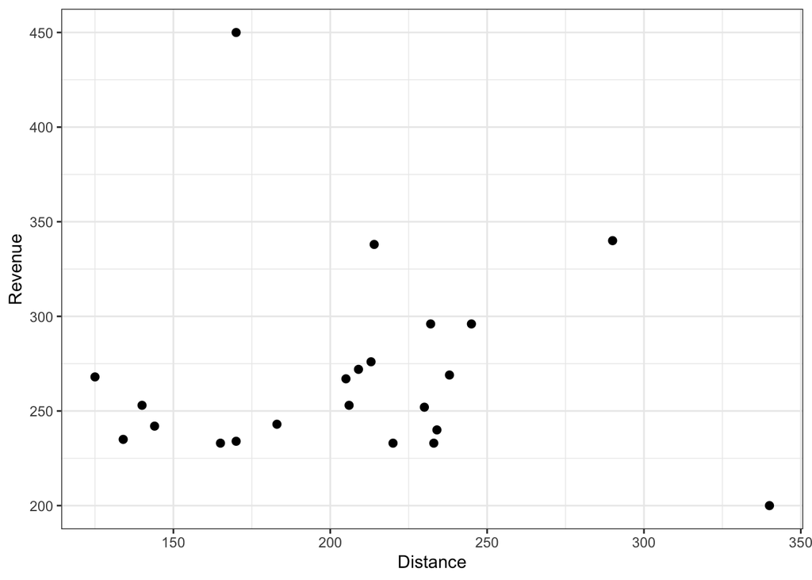

```r
airline_data %>%
  ggplot(aes(y = Revenue, x = Distance)) +
  geom_point(size = 2) +
  theme_bw()
```

**6b. Create a scatterplot with revenue (*Revenue*) on the *y*-axis and distance (*Population*) on the *x*-axis.**

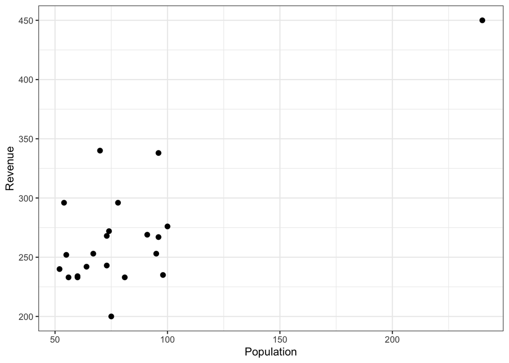

```r
airline_data %>%
  ggplot(aes(y = Revenue, x = Population)) +
  geom_point(size = 2) +
  theme_bw()
```

**6c. Do you see anything strange in either of the scatterplots?**

**Let’s update the dataset and rerun the analysis.**

```r
airline_data <- airline_data %>% filter(Airport != 20)
```

**7. Using this updated dataset, model revenue (*Revenue*) as a function of distance (*Distance*) and population (*Population*). Remember to state the resulting model.**

```r
airline_data %>% linear_regression(outcome = Revenue,
                                   function_of = Distance + Population)
```

```
# A tibble: 3 × 7
  term        estimate std_error statistic lower_bound upper_bound p_value
  <chr>          <dbl>     <dbl>     <dbl>       <dbl>       <dbl> <chr>
1 (Intercept)  185.       54.9       3.36       69.2       300.    0.003
2 Distance       0.144     0.153     0.941      -0.178       0.466 0.359
3 Population     0.617     0.497     1.24       -0.428       1.66  0.231
```

**8. Provide brief interpretations for the slopes in the model.**

**9. How different are the interpretations from those in Q2?**

**10a. Use the appropriate hypothesis test to determine if distance is a significant predictor of revenue. Test at the $\alpha=0.05$ level. Remember to typeset your results.**

```r
airline_data %>% linear_regression(outcome = Revenue,
                                   function_of = Distance + Population)
```

```
# A tibble: 3 × 7
  term        estimate std_error statistic lower_bound upper_bound p_value
  <chr>          <dbl>     <dbl>     <dbl>       <dbl>       <dbl> <chr>
1 (Intercept)  185.       54.9       3.36       69.2       300.    0.003
2 Distance       0.144     0.153     0.941      -0.178       0.466 0.359
3 Population     0.617     0.497     1.24       -0.428       1.66  0.231
```

**10b. Use the appropriate hypothesis test to determine if population is a significant predictor of revenue. Test at the $\alpha=0.05$ level. Remember to typeset your results.**

```r
airline_data %>% linear_regression(outcome = Revenue,
                                   function_of = Distance + Population)
```

```
# A tibble: 3 × 7
  term        estimate std_error statistic lower_bound upper_bound p_value
  <chr>          <dbl>     <dbl>     <dbl>       <dbl>       <dbl> <chr>
1 (Intercept)  185.       54.9       3.36       69.2       300.    0.003
2 Distance       0.144     0.153     0.941      -0.178       0.466 0.359
3 Population     0.617     0.497     1.24       -0.428       1.66  0.231
```

**11. How different are the results for Q10 as compared to the full dataset’s analysis in Q3?**

**12. Use the appropriate hypothesis test to determine if this is a significant regression line. Test at the $\alpha=0.05$ level.**

```r
airline_data %>% significant_line(outcome = Revenue,
                                  function_of = Distance + Population)
```

```
Likelihood Ratio Test for Significant Regression Line:
Null: H₀: β₁ = β₂ = ... = βₖ = 0
Alternative: H₁: At least one βᵢ ≠ 0
Test statistic: χ²(2) = 2373.117
p-value: p = 0.371
Conclusion: Fail to reject the null hypothesis (p = 0.3712 ≥ α = 0.05)
```

**13. How different are the results for Q12 as compared to the full dataset’s analysis in Q4?**

**14. How well does the data fit the line? Find the adjusted $R^2$ value and comment on it.**

```r
airline_data %>% r_squared(outcome = Revenue,
                           function_of = Distance + Population)
```

```
[1] -9e-04
```

**15. How different are the results for Q14 as compared to the full dataset’s analysis in Q5?**

**16. What are you taking away from this assignment? Why do you think I chose this particular dataset for you?**